# Table of Contents

```
欢迎使用此模块,借此您可使用其中的多个工具进行资产量化择时的研究,包括:
1.择时信号能力分析函数:LongShort_Accuracy(close,signal)/Turning_Accuracy(close,signal,window_list)/ Timing_Visualize(close,signal)
2.多信号关联模式遍历工具: Connection_Search2(signals)/Connection_Search(signals)/Circuit_Search(factor_list)
3.辅助工具函数：逻辑运算/排列组合/多种移动平均算法
```

**更新:2020/11/3**

- 1.单资产择时策略: 增加了对我们单择时策略研究过程中把控和避免过拟合风险所作的工作的讨论。
- 2.策略间性质分析: 增加了多策略间相关性分析、轮动特征、策略表现与风险敞口使用效率、策略的趋势追随特征的讨论。
- 3.基准比较: 增加了闲置资金的票息收益,以及相对基准的时序稳健性比较。
- 4.额外考察: 增加了单信号寻优/信号集成两个环节的动态过程表现分析,以考察样本外表现的可靠性;另外展示了多策略组合在更早的表现展示稳健的策略效果。

# 1. 单资产择时策略

**信号参数并非极致的数据挖掘结果、简约的信号的集成方式过拟合风险较低、多维度的信号选择方式下策略更稳健可执行**

- 1.1 单资产的择时策略我们继承之前一篇研究方法,**通过两个步骤进行寻优**: (1)各资产单信号的参数寻优;(2)入选的信号池的串并联集成结果寻优。
- 1.2 为了在寻优过程中尽量减小数据挖掘的问题,我们在**寻优框架中加入了三点考虑**:
  - (1) **主动降低挖掘能力**:每个信号的参数网格设置非常稀疏,只试图探索是否明显更长/更短的参数更有效,并非从密集连续的参数中寻觅极致的优化结果;
  - (2) **提升优劣判别标准**：不同参数回测表现的优劣要求夏普比有20%以上的差别才算显著,否则就认定为回测表现无区别,必须进行交易特征/稳健性的对比完成择优;
  - (3) **多重维度进行择优**: 单信号和集成信号通过多个维度筛选: 要求具有显著领先的夏普比和收益回撤比,时序表现稳定占优,以及适宜的交易习惯(胜率不能低于40%,持仓期不低于4不大于60)。

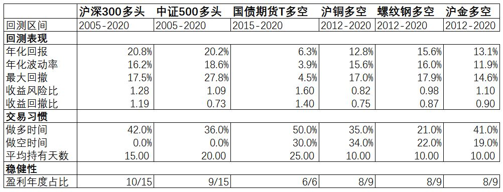

### 沪深300多头: 20050101-20200930

- **[并联:MACD(26/12/9)&[串联:SDD(100/0.1)&RSRS(40/0.2)]**
- 回测表现:20%+16%+17%+1.3;
- 交易特征:**42%时间做多,平均持有15天**,胜率47%,赔率4.3.
- 时序稳健性: 15年中5年亏损,最大年度亏损为08年的-10.7%,盈利年份均大于10%。

```
正在进行回测...
择时策略的回测表现为:
        多空双边策略   纯多头策略
年化回报   20.82%  20.82%
年化波动率  16.20%  16.20%
年内回撤   17.49%  17.49%
年化夏普     1.06    1.06
```

[interactive chart not shown]

|  | 2006 | 2007 | 2008 | 2009 | 2010 | 2011 | 2012 | 2013 | 2014 | 2015 | 2016 | 2017 | 2018 | 2019 | 2020 |
| --- | --- | --- | --- | --- | --- | --- | --- | --- | --- | --- | --- | --- | --- | --- | --- |
| 年度收益 | 1.040882 | 0.877901 | -0.107072 | 0.717913 | -0.008426 | -0.09648 | 0.106367 | 0.134615 | 0.356826 | 0.222937 | -0.0174 | 0.120991 | -0.097024 | 0.360878 | 0.129215 |

### 中证500多头: 20041231-20200930

- **[串联:MASS(40/0.7)&[并联:SDD(40/0)&MACD(35/15/12)]**
- 回测表现:20%+18.6%+27%+1.1;
- 交易特征:**36%时间做多,平均持有20天**,胜率48%,赔率7倍。
- 时序稳健性: 15年中6年亏损,最大年度亏损为08年的18%,其余年份的亏损多在10%以内。

```
正在进行回测...
择时策略的回测表现为:
        多空双边策略   纯多头策略
年化回报   20.19%  20.19%
年化波动率  18.64%  18.64%
年内回撤   27.82%  27.82%
年化夏普     0.89    0.89
```

[interactive chart not shown]

|  | 2006 | 2007 | 2008 | 2009 | 2010 | 2011 | 2012 | 2013 | 2014 | 2015 | 2016 | 2017 | 2018 | 2019 | 2020 |
| --- | --- | --- | --- | --- | --- | --- | --- | --- | --- | --- | --- | --- | --- | --- | --- |
| 年度收益 | 0.617603 | 1.753947 | -0.18644 | 0.771898 | 0.139068 | -0.063885 | -0.024369 | 0.108532 | 0.166858 | 0.839662 | -0.107356 | -0.018848 | -0.086541 | 0.137585 | 0.113704 |

### 国债期货T多空: 20150101-20200930

- **[并联:[串联:双均线多头(90/5)&RSI多头(15)]&RSRS多空(40/0.05)]**
- 回测表现：6.3%+3.9%+4.5%;
- 交易特征：**50%时间做多,平均持有30天,30%时间做空;平均持有20天**; 多头胜率75%,赔率4倍;空头胜率56%,赔率2.7; 20%时间震荡信号准确。
- 时序稳健性: 15年至今每年都盈利,2017年最小盈利1.6%,18年至今三年策略表现提升年化7%。

```
正在进行回测...
择时策略的回测表现为:
       多空双边策略  纯多头策略  纯空头策略
年化回报   6.30%  4.21%  2.17%
年化波动率  3.88%  2.87%  2.68%
年内回撤   4.51%  3.06%  3.89%
年化夏普    0.78   0.33  -0.41
```

[interactive chart not shown]

|  | 2015 | 2016 | 2017 | 2018 | 2019 | 2020 |
| --- | --- | --- | --- | --- | --- | --- |
| 年度收益 | 0.025386 | 0.042532 | 0.016341 | 0.091078 | 0.058557 | 0.063711 |

### 沪铜期货多空: 20120101-20200930

```
正在进行回测...
择时策略的回测表现为:
        多空双边策略   纯多头策略   纯空头策略
年化回报   12.78%   7.03%   5.79%
年化波动率  15.56%  10.96%  11.06%
年内回撤   17.08%  10.45%  15.12%
年化夏普     0.58    0.30    0.19
```

[interactive chart not shown]

|  | 2012 | 2013 | 2014 | 2015 | 2016 | 2017 | 2018 | 2019 | 2020 |
| --- | --- | --- | --- | --- | --- | --- | --- | --- | --- |
| 年度收益 | 0.165905 | -0.041542 | -0.040758 | 0.274821 | 0.267497 | 0.106379 | 0.004886 | 0.017798 | 0.401388 |

### 螺纹钢期货多空: 20120101-20200930

- **[并联:MASS空头(20/0.2)&[串联:RSRS多头(40/0.2)&MASS多头(20/0.6)]]**
  - 回测表现: **16% + 16% + 18%**
  - 交易特征: 21%时间做多,平均持有12天,胜率50%,赔率4.4; 22%时间做空,平均持有10天,胜率55%,赔率1.6。**一半的时间不参与**
  - 时序稳健性: 12年至今共9年中只有14/20年小幅亏损5%。

```
正在进行回测...
择时策略的回测表现为:
        多空双边策略   纯多头策略   纯空头策略
年化回报   15.60%  11.91%   4.31%
年化波动率  16.01%  13.20%   9.56%
年内回撤   17.92%  13.37%  17.93%
年化夏普     0.74    0.62    0.07
```

[interactive chart not shown]

|  | 2012 | 2013 | 2014 | 2015 | 2016 | 2017 | 2018 | 2019 | 2020 |
| --- | --- | --- | --- | --- | --- | --- | --- | --- | --- |
| 年度收益 | 0.183431 | 0.081945 | -0.009018 | 0.133713 | 0.988122 | 0.08408 | 0.072699 | 0.065126 | -0.054777 |

### 沪金期货多空: 20120101-20200930

- **[并联:MACD多头(26/12/9)&[并联:RSI多空(10)&RSRS多空(20/0.1)]]**
  - 回测表现: **13% + 12% + 15%** ;
  - 交易特征: **41%时间做多,平均持有12天,19%时间做空,平均持有8天**; 多头胜率49%,赔率2;空头胜率65%,赔率2。
  - 时序稳健性: 9年间只有17年小幅亏损3%

```
正在进行回测...
择时策略的回测表现为:
        多空双边策略   纯多头策略   纯空头策略
年化回报   13.10%   7.43%   5.78%
年化波动率  11.87%   9.58%   7.12%
年内回撤   14.57%  15.69%  11.26%
年化夏普     0.79    0.39    0.29
```

[interactive chart not shown]

|  | 2012 | 2013 | 2014 | 2015 | 2016 | 2017 | 2018 | 2019 | 2020 |
| --- | --- | --- | --- | --- | --- | --- | --- | --- | --- |
| 年度收益 | 0.052136 | 0.179549 | 0.099004 | 0.201938 | 0.210722 | -0.03361 | 0.061235 | 0.225199 | 0.127796 |

# 2. 各策略的性质分析

**各策略均体现明确的趋势追随风格,并且策略间相关性低、轮动特征明显、风险敞口利用效率高的三大特点有利于多策略组合的表现。**

- 2.1 多策略相关性分析:
  - 各策略收益相关性极低,风险分散化潜力大;
  - 各年度表现轮动特征明显,使得多资产组合在不同阶段表现更稳健。
- 2.2 多策略条件特征分析:
  - 除铜以外的各策略表现不好时风险敞口(信号时间占比)通常占用较少,策略轮动的利用效率高;
  - 策略信号与资产趋势性显著相关,展现明确的趋势策略风格。

## 多策略相关性分析

**多策略表现相关性极低,各年度表现轮动特征明显**

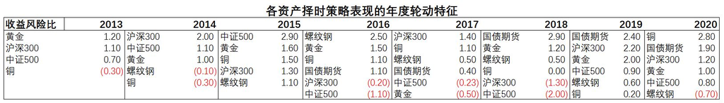

策略相关性

|  | HS300 | ZZ500 | T | CU | RB | AU |
| --- | --- | --- | --- | --- | --- | --- |
| HS300 | 1.000000 | 0.484706 | -0.104194 | 0.058084 | 0.027387 | -0.097239 |
| ZZ500 | 0.484706 | 1.000000 | -0.078763 | -0.034202 | 0.063278 | -0.033749 |
| T | -0.104194 | -0.078763 | 1.000000 | -0.008295 | 0.022965 | 0.048657 |
| CU | 0.058084 | -0.034202 | -0.008295 | 1.000000 | 0.160933 | -0.010646 |
| RB | 0.027387 | 0.063278 | 0.022965 | 0.160933 | 1.000000 | 0.006488 |
| AU | -0.097239 | -0.033749 | 0.048657 | -0.010646 | 0.006488 | 1.000000 |

策略表现轮动

|  | HS300 | ZZ500 | T | CU | RB | AU |
| --- | --- | --- | --- | --- | --- | --- |
| 2012-12-31-2013-12-31 | 1.110145 | 0.735732 | 0.000000 | -0.357051 | 0.959560 | 1.184943 |
| 2013-12-31-2014-12-31 | 2.045189 | 1.102485 | 0.000000 | -0.277323 | -0.133702 | 1.055540 |
| 2014-12-31-2015-12-31 | 1.281580 | 2.867374 | 0.000000 | 1.534020 | 1.053487 | 1.605986 |
| 2015-12-31-2016-12-31 | -0.199533 | -1.105640 | 1.064956 | 1.125219 | 2.490902 | 1.495066 |
| 2016-12-31-2017-12-31 | 1.391521 | -0.230628 | 0.408471 | 0.717499 | 0.463140 | -0.506420 |
| 2017-12-31-2018-12-31 | -1.271566 | -1.964801 | 2.898500 | 0.037178 | 0.516032 | 1.177903 |
| 2018-12-31-2019-12-31 | 2.150524 | 0.904663 | 2.376459 | 0.229082 | 0.602847 | 2.008555 |
| 2019-12-31-2020-12-31 | 1.177656 | 0.804890 | 1.902926 | 2.767257 | -0.710580 | 0.949125 |

## 多策略的条件特征分析

**策略表现与信号占比正相关,风险敞口使用效率高; 信号占比与市场趋势性正相关,趋势策略特征显著**

- 1.各策略表现与时间占比:
  - 方法: 统计半年度/季度策略收益与对应区间策略有非0信号的时间占比,用以分析策略的风险敞口使用效率,例如表现差的时候如果信号占比很低则有利于在给定的目标风险敞口下对其他策略的权重提升。
  - 结论: **除了沪铜策略以外,其他五个策略的策略表现与信号时间占比均呈显著正相关,想必在多策略组合中的目标风险预算的使用效率高。**
- 2.策略信号占比与资产表现:
  - 方法: 统计每半年度/季度区间的非0信号天数占比与对应区间资产趋势性(用年化收益/年化波动率代表,该值接近0属于震荡市趋势性弱)的关系,用以分析策略信号的趋势追随特征。
  - 结论: **各策略的信号时间占比均与资产的趋势性显著相关,做多/做空信号分别在市场上涨/下跌趋势中增加信号占比,体现显著的趋势追随特征。**

### 股票：沪深300&中证500多头

- 策略表现越差的阶段信号占用时间越少,风险敞口占用少; 股指正趋势性越强多头信号占比越大,显著的趋势追随特征。

沪深300: 20060101至今半年窗口

[interactive chart not shown]

中证500: 20060101至今半年窗口

[interactive chart not shown]

### 国债期货：

- 策略表现越差的阶段信号占用时间越少,风险敞口占用少; T正趋势性越强多头信号占比越大,T负趋势性越强空头信号占比越大,呈现显著的趋势追随特征。

[interactive chart not shown]

### 沪铜期货:

- **策略表现与占用时间无显著关系,风险敞口利用效率低;** CU正趋势性越强多头信号占比越大,CU负趋势性越强空头信号占比越大,呈现显著的趋势追随特征。

[interactive chart not shown]

### 螺纹钢期货:

- 策略表现越差的阶段信号占用时间越少,风险敞口占用少; RB正趋势性越强多头信号占比越大,RB负趋势性越强空头信号占比越大,呈现显著的趋势追随特征。

[interactive chart not shown]

### 沪金期货:

- 策略表现越差的阶段信号占用时间越少,风险敞口占用少; AU正趋势性越强多头信号占比越大,AU负趋势性越强空头信号占比越大,呈现显著的趋势追随特征。

[interactive chart not shown]

# 3. 多策略组合

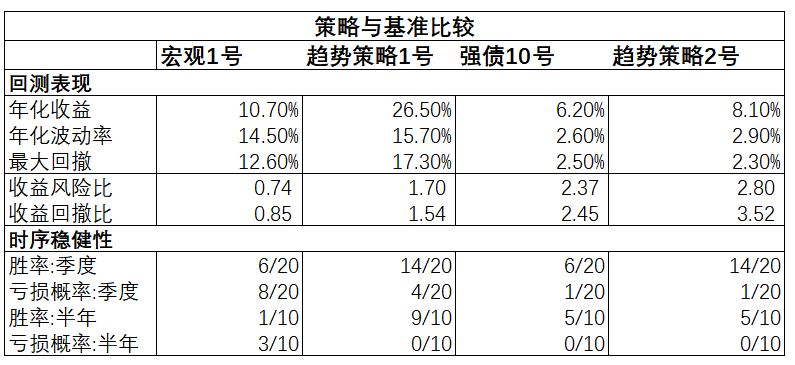

## 基准表现

- 时间区间: 策略净值以2015/10/01开始,到2020/09/30结束,故以此相同区间计算基准表现。
- 基准表现: **宏观1号:** 年化收益10.7%,年化波动14.5%,最大回撤12.6%；**强债10号:**年化收益6.2%,年化波动2.6%,最大回撤2.5%。

|  | HG1 | Q10 |
| --- | --- | --- |
| 年化回报 | 0.107464 | 0.061796 |
| 年化波动率 | 0.144740 | 0.026126 |
| 最大回撤 | 0.126037 | 0.025263 |

## 组合构建

- **风险贡献平价方法**: 每次换仓时,计算入选资产的历史60天收益率协方差矩阵,从而计算权重使得**各资产对组合的波动率贡献相等**且**组合预期波动率为14.5%/2.6%。**

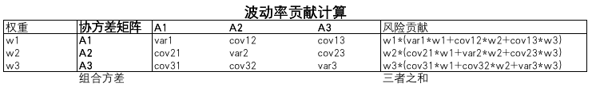

- **纳入现金收益**: 策略均以期货主力合约来表达多空观点,在控制目标波动率情况下保证金占用有限,故纳入闲置资金的无风险收益,以同业存单总财富指数计算现金收益。
- **组合表现**:
  - 宏观组合:年化收益26.5%,波动率15.7%,最大回撤17.3%。
  - 强债组合:年化收益8.1%,波动率2.9%,最大回撤2.3%。

|  | 策略表现:对标宏观1 | 策略表现:对标强债10 |
| --- | --- | --- |
| 年化回报 | 0.266612 | 0.081052 |
| 年化波动率 | 0.157087 | 0.028919 |
| 年内回撤 | 0.173181 | 0.023030 |

[interactive chart not shown]

## 基准比较

### 回测表现比较

```
            年化回报     年化波动率      最大回撤     收益风险比     收益回撤比
宏观1号    0.107464  0.144740  0.126037  0.742462  0.852635
趋势策略1号  0.266612  0.157087  0.173181  1.697226  1.539498
```

[interactive chart not shown]

```
            年化回报     年化波动率      最大回撤     收益风险比     收益回撤比
强债10号   0.061796  0.026126  0.025263  2.365305  2.446109
趋势策略2号  0.081052  0.028919  0.023030  2.802684  3.519399
```

[interactive chart not shown]

### 时序稳健性

[interactive chart not shown]

# 4. 稳健性测试

- 4.1 **实验1: 信号参数寻优的样本外表现**
  - 目的: 检测各资产的**单择时信号样本内最优参数在样本外的投资表现**,考察我们参数优化的过拟合风险。
  - **结果**: 表现结果而论,单择时信号参数寻优后的样本外表现只有微小的衰减,没体现过拟合风险。再看历史寻优结果,随着窗口推移,参数寻优结果逐渐与静态参数选择一致,另外不完全一致的选择下也体现了非常一致的长/短参数特征,并未出现明显的背离,**其实这种表现与我们筛选信号时对时序稳健性的要求有紧密的关系。**。
- 4.2 **实验2: 信号集成寻优的样本外表现**
  - 目的: 检测各资产的**信号集成在样本内最优模式的样本外表现**,考察信号集成优化的过拟合风险。
  - **结果**: 动态集成方法动态寻优结果的样本外表现均呈现非常显著的正收益,相对全样本寻优的表现只有小幅的弱化。**实际上我们的串并联结合方法本身不是复杂精密的算法,不具有明显的数据挖掘特征,尤其是三信号的简单串并联组合。表现的相对弱化可能来自于动态寻参样本内较使得优化结果的普适性相对不足,另一方面整体样本只能划分最多6次,使得样本外的表现对比缺乏足够的统计稳健性。在此数据不足背景下,样本外检验依然减弱了我们的过拟合担忧。**

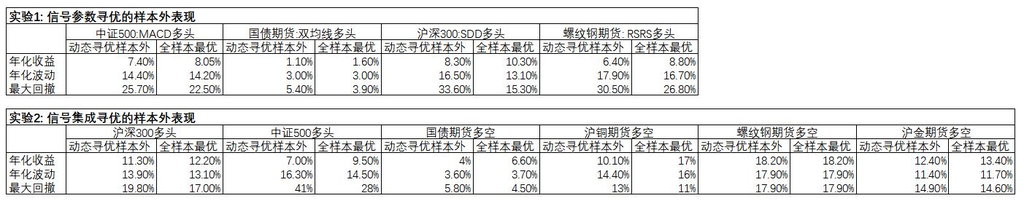

- 4.3 **实验3: 真样本外(2012年-2015年)**
  - 目的: 扣除国债期货后得以使用更早的数据展示多策略组合的表现,用于体现多策略对单策略表现提升的时序稳健性。
  - **结果:** 除国债期货后的五个策略组合在2012-2015年的收益波动比/收益回撤比与后续区间表现一致,多策略组合的效果稳健。
- 4.4 **结论:**
  - 1.稀疏的参数设置保证了样本内寻优的过度数据挖掘特征弱,过拟合风险很小;
  - 2.串并联组合的简单集成算法也并非复杂精致的拟合工具,只是简单的规律测试,事后检验同样证实了这一点。
  - 3.另外,我们在每个资产集成信号择时策略的研究中一直注意信号的多维度对比,不只是选择回测表现最佳的,信号交易特征/时序稳健性/集成信号的易理解性均降低了过拟合风险。=
  - 4.最后,此策略有着鲜明的趋势追随特征,策略内核为对市场趋势性的信仰,最终得到的信号也多为常见的趋势信号经过简单的集成,所以在样本外依然是趋势信号,并非存在极大风险的黑匣子。

## 实验1: 信号参数寻优的样本外表现

- **信号选择:** 我们从(6个资产各3个信号)共18个入选信号中,选择过拟合可能较大的信号进行检验,包括:参数较不常见的中证500的MACD(35,15,12)多头和国债期货双均线(90,5)多头;以及逻辑不够直观的沪深300的SDD(100,0.1)多头和螺纹钢RSRS(40/0.2)多头。其余信号主要是参数常见的均线类策略和传统参数的相对强弱RSI信号,过拟合风险低。
- **实验方法:** 每两年滚动(国债期货1年滚动),以过去全部可得数据为样本内,对不同参数组合下的信号表现进行寻优,并将样本内最佳信号作为后续两年的择时信号,对其样本外表现进行回测。

中证500: MACD(35/15/12)多头

```
2010-01-01 后2年参数为: (42, 20, 15)
2012-01-01 后2年参数为: (42, 20, 15)
2014-01-01 后2年参数为: (42, 20, 15)
2016-01-01 后2年参数为: (35, 15, 12)
2018-01-01 后2年参数为: (35, 15, 12)
2020-01-01 后2年参数为: (42, 20, 15)
```

[interactive chart not shown]

|  | 全局样本内最优 | 动态优化样本外 |
| --- | --- | --- |
| 年化回报 | 0.080533 | 0.073860 |
| 年化波动率 | 0.142280 | 0.144432 |
| 年内回撤 | 0.224566 | 0.256691 |
| 年化夏普 | 0.566021 | 0.511381 |

国债期货: 双均线(90,5)多头

```
2016-01-01 后1年参数为: (90, 15)
2017-01-01 后1年参数为: (90, 15)
2018-01-01 后1年参数为: (90, 5)
2019-01-01 后1年参数为: (90, 5)
2020-01-01 后1年参数为: (90, 5)
```

[interactive chart not shown]

|  | 全局样本内最优 | 动态优化样本外 |
| --- | --- | --- |
| 年化回报 | 0.015826 | 0.011497 |
| 年化波动率 | 0.029831 | 0.029696 |
| 年内回撤 | 0.038533 | 0.054148 |
| 年化夏普 | 0.530505 | 0.387171 |

沪深300: SDD(100,0.1)多头

```
2010-01-01 开始的后2年参数为: (100, 0)
2012-01-01 开始的后2年参数为: (100, 0)
2014-01-01 开始的后2年参数为: (100, 0)
2016-01-01 开始的后2年参数为: (100, 0)
2018-01-01 开始的后2年参数为: (100, 0.1)
2020-01-01 开始的后2年参数为: (100, 0.1)
```

[interactive chart not shown]

|  | 全局样本内最优 | 动态优化样本外 |
| --- | --- | --- |
| 年化回报 | 0.103289 | 0.083083 |
| 年化波动率 | 0.130786 | 0.165339 |
| 年内回撤 | 0.153032 | 0.335785 |
| 年化夏普 | 0.789757 | 0.502502 |

螺纹钢期货: RSRS(40/0.2多头)

```
2014-01-01 后2年参数为: (60, 0.1)
2016-01-01 后2年参数为: (60, 0.2)
2018-01-01 后2年参数为: (20, 0.1)
2020-01-01 后2年参数为: (20, 0.2)
```

[interactive chart not shown]

|  | 全局样本内最优 | 动态优化样本外 |
| --- | --- | --- |
| 年化回报 | 0.087627 | 0.064335 |
| 年化波动率 | 0.166454 | 0.179106 |
| 年内回撤 | 0.268445 | 0.304975 |
| 年化夏普 | 0.526432 | 0.359201 |

## 实验2: 信号集成寻优的样本外表现

- **实验方法:** 每两年滚动(国债期货1年滚动),以过去全部可得数据为样本内,对每个资产的信号池进行串并联集成寻优,并将样本内最佳集成信号作为后续两年(一年)的择时信号,对其样本外表现进行回测。

沪深300多头: [并联:MACD(26/12/9)&[串联:SDD(100/0.1)&RSRS(40/0.2)]

```
2010-01-01 开始的后2年参数为: 并联结果:100日单向偏差纯多头信号:沪深300:日内最高价&串联结果:26+12+9日MACD纯多头信号:沪深300:收盘价&40日RSRS纯多头信号:沪深300:日内最高价
2012-01-01 开始的后2年参数为: 并联结果:100日单向偏差纯多头信号:沪深300:日内最高价&串联结果:26+12+9日MACD纯多头信号:沪深300:收盘价&40日RSRS纯多头信号:沪深300:日内最高价
2014-01-01 开始的后2年参数为: 并联结果:100日单向偏差纯多头信号:沪深300:日内最高价&串联结果:26+12+9日MACD纯多头信号:沪深300:收盘价&40日RSRS纯多头信号:沪深300:日内最高价
2016-01-01 开始的后2年参数为: 并联结果:100日单向偏差纯多头信号:沪深300:日内最高价&串联结果:26+12+9日MACD纯多头信号:沪深300:收盘价&40日RSRS纯多头信号:沪深300:日内最高价
2018-01-01 开始的后2年参数为: 并联结果:100日单向偏差纯多头信号:沪深300:日内最高价&串联结果:26+12+9日MACD纯多头信号:沪深300:收盘价&40日RSRS纯多头信号:沪深300:日内最高价
2020-01-01 开始的后2年参数为: 并联结果:26+12+9日MACD纯多头信号:沪深300:收盘价&串联结果:100日单向偏差纯多头信号:沪深300:日内最高价&40日RSRS纯多头信号:沪深300:日内最高价
```

[interactive chart not shown]

|  | 全局样本内最优 | 动态优化样本外 |
| --- | --- | --- |
| 年化回报 | 0.121971 | 0.113441 |
| 年化波动率 | 0.131726 | 0.139433 |
| 年内回撤 | 0.170430 | 0.198199 |
| 年化夏普 | 0.925948 | 0.813590 |

中证500多头: [串联:MASS(40/0.7)&[并联:SDD(40/0)&MACD(35/15/12)]

```
2010-01-01 开始的后2年参数为: 并联结果:40日单向偏差纯多头信号:中证500:日内最高价&串联结果:MASS纯多头信号:中证500:收盘价&35+15+12日MACD纯多头信号:中证500:收盘价
2012-01-01 开始的后2年参数为: 并联结果:40日单向偏差纯多头信号:中证500:日内最高价&串联结果:MASS纯多头信号:中证500:收盘价&35+15+12日MACD纯多头信号:中证500:收盘价
2014-01-01 开始的后2年参数为: 串联结果:MASS纯多头信号:中证500:收盘价&并联结果:35+15+12日MACD纯多头信号:中证500:收盘价&40日单向偏差纯多头信号:中证500:日内最高价
2016-01-01 开始的后2年参数为: 串联结果:MASS纯多头信号:中证500:收盘价&并联结果:35+15+12日MACD纯多头信号:中证500:收盘价&40日单向偏差纯多头信号:中证500:日内最高价
2018-01-01 开始的后2年参数为: 并联结果:40日单向偏差纯多头信号:中证500:日内最高价&串联结果:MASS纯多头信号:中证500:收盘价&35+15+12日MACD纯多头信号:中证500:收盘价
2020-01-01 开始的后2年参数为: 串联结果:MASS纯多头信号:中证500:收盘价&并联结果:35+15+12日MACD纯多头信号:中证500:收盘价&40日单向偏差纯多头信号:中证500:日内最高价
```

[interactive chart not shown]

|  | 全局样本内最优 | 动态优化样本外 |
| --- | --- | --- |
| 年化回报 | 0.095387 | 0.069871 |
| 年化波动率 | 0.145458 | 0.162909 |
| 年内回撤 | 0.278198 | 0.411621 |
| 年化夏普 | 0.655770 | 0.428894 |

国债期货T多空: [并联:[串联:双均线多头(90/5)&RSI多头(15)]&RSRS多空(40/0.05)]

```
2017-01-01 开始的后1年参数为: 并联结果:15日相对强弱纯多头信号:T指数:close&串联结果:5+90日双均线纯多头信号:T指数:close&40日RSRS多空信号:T指数:high
2018-01-01 开始的后1年参数为: 并联结果:15日相对强弱纯多头信号:T指数:close&并联结果:5+90日双均线纯多头信号:T指数:close&40日RSRS多空信号:T指数:high
2019-01-01 开始的后1年参数为: 并联结果:40日RSRS多空信号:T指数:high&串联结果:5+90日双均线纯多头信号:T指数:close&15日相对强弱纯多头信号:T指数:close
2020-01-01 开始的后1年参数为: 并联结果:40日RSRS多空信号:T指数:high&串联结果:5+90日双均线纯多头信号:T指数:close&15日相对强弱纯多头信号:T指数:close
```

[interactive chart not shown]

|  | 全局样本内最优 | 动态优化样本外 |
| --- | --- | --- |
| 年化回报 | 0.065983 | 0.039139 |
| 年化波动率 | 0.037232 | 0.035697 |
| 年内回撤 | 0.044734 | 0.057742 |
| 年化夏普 | 1.772199 | 1.096417 |

沪铜期货多空: [并联:双均线多空(20/5)&[并联:RSI多空(10)&RSRS多空(20/0.2/-0.1)]]

```
2015-01-01 开始的后2年参数为: 串联结果:并联结果:20/0.2RSRS&20/0.1RSRS&并联结果:5+20日双均线多空信号:CU指数:close&10日相对强弱多空信号:CU指数:close
2017-01-01 开始的后2年参数为: 并联结果:10日相对强弱多空信号:CU指数:close&串联结果:5+20日双均线多空信号:CU指数:close&并联结果:20/0.2RSRS&20/0.1RSRS
2019-01-01 开始的后2年参数为: 并联结果:10日相对强弱多空信号:CU指数:close&串联结果:5+20日双均线多空信号:CU指数:close&并联结果:20/0.2RSRS&20/0.1RSRS
```

[interactive chart not shown]

|  | 全局样本内最优 | 动态优化样本外 |
| --- | --- | --- |
| 年化回报 | 0.172343 | 0.101028 |
| 年化波动率 | 0.160201 | 0.143986 |
| 年内回撤 | 0.112725 | 0.129808 |
| 年化夏普 | 1.075795 | 0.701651 |

螺纹钢期货多空: [并联:MASS空头(20/0.2)&[串联:RSRS多头(40/0.2)&MASS多头(20/0.6)]]

```
2015-01-01 开始的后2年参数为: 并联结果:MASS纯空头信号:RB指数:close&串联结果:40日RSRS纯多头信号:RB指数:high&MASS纯多头信号:RB指数:close
2017-01-01 开始的后2年参数为: 并联结果:MASS纯空头信号:RB指数:close&串联结果:40日RSRS纯多头信号:RB指数:high&MASS纯多头信号:RB指数:close
2019-01-01 开始的后2年参数为: 并联结果:MASS纯空头信号:RB指数:close&串联结果:40日RSRS纯多头信号:RB指数:high&MASS纯多头信号:RB指数:close
```

[interactive chart not shown]

|  | 全局样本内最优 | 动态优化样本外 |
| --- | --- | --- |
| 年化回报 | 0.182293 | 0.182293 |
| 年化波动率 | 0.178744 | 0.178744 |
| 年内回撤 | 0.179205 | 0.179205 |
| 年化夏普 | 1.019852 | 1.019852 |

沪金期货多空: [并联:MACD多头(26/12/9)&[并联:RSI多空(10)&RSRS多空(20/0.1)]]

```
2015-01-01 开始的后2年参数为: 并联结果:10日相对强弱多空信号:AU指数:close&并联结果:26+12+9日MACD纯多头信号:AU指数:close&20日RSRS多空信号:AU指数:high
2017-01-01 开始的后2年参数为: 并联结果:10日相对强弱多空信号:AU指数:close&并联结果:26+12+9日MACD纯多头信号:AU指数:close&20日RSRS多空信号:AU指数:high
2019-01-01 开始的后2年参数为: 并联结果:10日相对强弱多空信号:AU指数:close&并联结果:26+12+9日MACD纯多头信号:AU指数:close&20日RSRS多空信号:AU指数:high
```

[interactive chart not shown]

|  | 全局样本内最优 | 动态优化样本外 |
| --- | --- | --- |
| 年化回报 | 0.134241 | 0.123665 |
| 年化波动率 | 0.116645 | 0.113864 |
| 年内回撤 | 0.145685 | 0.149055 |
| 年化夏普 | 1.150853 | 1.086072 |

## 实验3: 真样本外(2012年-2015年)

- **实验方法**: 国债期货存续较晚限制了多策略组合回测的区间长度,为此我们扣除国债期货并从2012年开始回测至2015年,检测趋势策略在更早区间的表现,**虽然各子策略的优化用到这段数据,但多策略在更早区间的表现与后续区间表现一致,实则也是表现稳健的一种体现。**。(另:作为无风险利率的同存指数太晚,替换为短融指数)

```
       策略表现:对标宏观1  策略表现:对标强债10
年化回报     0.275372     0.090312
年化波动率    0.121119     0.022822
年内回撤     0.082035     0.012893
```

[interactive chart not shown]